# n-back

上野莉緒（2412A06）

## 2. 方法(Method)

### 装置と材料

実験プログラムはjsPsychを用いて作成し、GitHub Pages上で公開した。参加者は各自のスマートフォンまたはPCのブラウザから参加した。

### 手続き

課題は「1-back条件」と「2-back条件」の2つで構成された（条件順序は参加者間でカウンターバランスを実施）。

1. 参加者は画面中央を注視し、次々に提示されるアルファベットを確認した。
2. **1-back条件**では「直前に出た文字と同じ場合」、**2-back条件**では「2つ前に出た文字と同じ場合」にキーボードの「スペースキー」を押すよう求められた（一致しない場合は不押下）。
3. 各条件の試行間に十分な休憩を挟んだ。

## 3. 結果 (Results)

以下の通り、対応のあるt検定を行った。

```
=== 対応のあるt検定の結果 ===
```

```
    Paired t-test

data:  data_1back and data_2back
t = -1.633, df = 4, p-value = 0.1778
alternative hypothesis: true mean difference is not equal to 0
95 percent confidence interval:
 -0.36002913  0.09336246
sample estimates:
mean difference
     -0.1333333
```

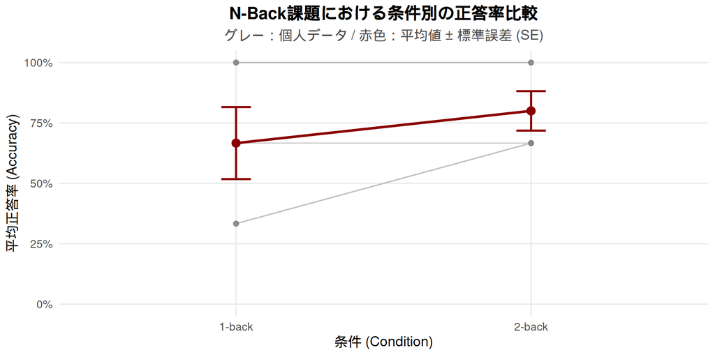

## 4. 考察 (Discussion)

分析の結果、仮説は指示されなかった。(有意な差は認められなかった)。（$t(4) = -1.63$, $p = .178$）。1-back条件（低負荷）と2-back条件（高負荷）の間で正答率に意味のある差は見られず（平均差 $= -0.13$, $95\% \text{ CI} [-0.36, 0.09]$）、負荷の違いによるパフォーマンスの低下は確認されなかった。また、本実験の限界として得られたデータ数が予定していた人数に達しなかったため、正確なデータが得られなかったと考えられる。

## 5. 引用文献 (References)

金原一宏, 鈴木那奈, 大城昌平, and 水池千尋. 2010. “ラベンダーの芳香刺激が作業効率に及ぼす影響.” *理学療法学Supplement* 2009: B4P3073–73. https://doi.org/10.14900/cjpt.2009.0.B4P3073.0.